# Loading and preprocessing the data

- URL and name of data as provided in assignment

```r
    # constants
    zip_file_url <- 'https://d396qusza40orc.cloudfront.net/repdata/data/activity.zip'
    zip_file_name <- 'activity.zip'
    data_file_name <- 'activity.csv'

    # install and/or load Hadley's ggplot2
    package <- 'ggplot2'

    if(package %in% rownames(installed.packages()) == FALSE) {install.packages(package)}
    do.call(library, as.list(eval(package)))
```

## Loading and preprocessing the data

### Show any code that is needed to

1. Load the data (i.e. read.csv())

```r
    # Download the data from url
    if ( !file.exists( zip_file_name) ) {
      download.file( url= zip_file_url,
                    destfile= zip_file_name,
                    method= "curl")
      unzip( zip_file_name)
    }

    # unzip data
    if ( !file.exists( data_file_name) ) {
      unzip(zipfile = data_file_name )
    }

    # load data
    activity <- read.csv(data_file_name,
                         colClasses = c("integer",
                                        "Date",
                                        "factor"))
```

1. Process/transform the data (if necessary) into a format suitable for your analysis

```r
    # summarize data
    summary(activity)
```

```
##      steps             date               interval
##  Min.   :  0.00   Min.   :2012-10-01   0      :   61
##  1st Qu.:  0.00   1st Qu.:2012-10-16   10     :   61
##  Median :  0.00   Median :2012-10-31   100    :   61
##  Mean   : 37.38   Mean   :2012-10-31   1000   :   61
##  3rd Qu.: 12.00   3rd Qu.:2012-11-15   1005   :   61
##  Max.   :806.00   Max.   :2012-11-30   1010   :   61
##  NA's   :2304                          (Other):17202
```

```r
    # ignore NA steps as per instructions
    ignoreNA <- na.omit(activity)

    summary(ignoreNA)
```

```
##      steps             date               interval
##  Min.   :  0.00   Min.   :2012-10-02   0      :   53
##  1st Qu.:  0.00   1st Qu.:2012-10-16   10     :   53
##  Median :  0.00   Median :2012-10-29   100    :   53
##  Mean   : 37.38   Mean   :2012-10-30   1000   :   53
##  3rd Qu.: 12.00   3rd Qu.:2012-11-16   1005   :   53
##  Max.   :806.00   Max.   :2012-11-29   1010   :   53
##                                        (Other):14946
```

## What is mean total number of steps taken per day?

##### For this part of the assignment, you can ignore the missing values in the dataset.

```r
  # aggregate steps per day throughout all days
  steps.per.day <- aggregate(list(steps = ignoreNA$steps),
                             list(date = ignoreNA$date),
                             sum,
                             na.rm=TRUE)
```

### Make a histogram of the total number of steps taken each day

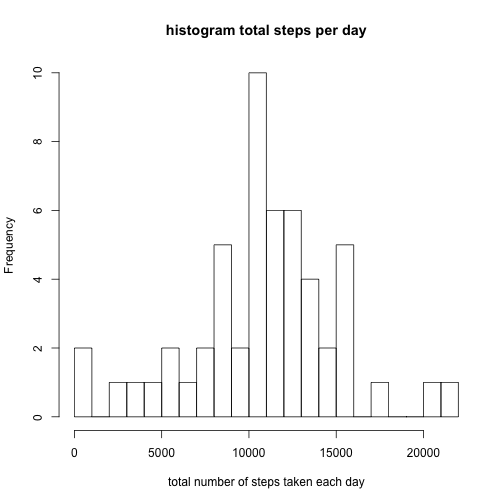

```r
  # draw histogram of total steps per day
  hist(steps.per.day$steps,
       breaks=30,
       xlab="total number of steps taken each day",
       main="histogram total steps per day")
```

### Calculate and report the mean and median total number of steps taken per day

```r
  # calculate mean and median steps per day
  stepsMean <- mean(steps.per.day$steps)
  stepsMedian <- median(steps.per.day$steps)
```

- There were 10,766 mean steps per day, and 10,765 median steps per day.

## What is the average daily activity pattern?

Make a time series plot (i.e. type = “l”) of the 5-minute interval (x-axis) and the average number of steps taken, averaged across all days (y-axis)

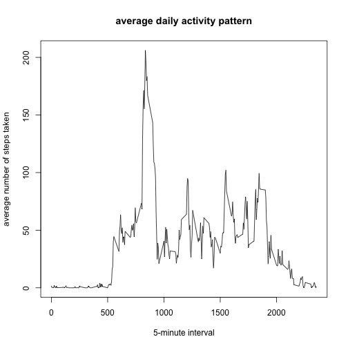

```r
# calculate the average steps for each interval
interval.mean <- aggregate(list(steps= ignoreNA$steps),
                           list(interval= ignoreNA$interval),
                           mean,
                           na.rm=TRUE)

#convert the interval from a factor back into an integer
interval.mean$interval <-  as.integer(as.character(interval.mean$interval))

#order data by interval
interval.mean <- interval.mean[order(interval.mean$interval),]

#create plot
plot( interval.mean$interval,
     interval.mean$steps,
     type="l",
     main="average daily activity pattern",
     xlab="5-minute interval",
     ylab="average number of steps taken")
```

Which 5-minute interval, on average across all the days in the dataset, contains the maximum number of steps?

```r
  #find the interval row with the max average steps
  intervalMean.max <- interval.mean[interval.mean$steps == max(interval.mean$steps), ]
```

- The 835 interval contains on average the max number of steps (at 206 steps).